# Mental health-related quality of life (SF-12 MCS) in adults with chronic disease

Dataset 8: Patient activation for self-management in chronic disease

RSR feasibility analysis

2026-08-03

# Introduction

Mental health-related quality of life in long-term physical illness is shaped at least as much by a patient’s social and economic circumstances as by their diagnosis. These data come from a cross-sectional survey of 1,154 Dutch adults treated in primary and secondary care for type 2 diabetes, COPD, chronic heart failure or chronic renal disease (Bos-Touwen et al., *PLoS ONE* 2015;10(5):e0126400), which recorded living arrangements, financial distress and perceived social support alongside the SF-12. Identifying the social circumstances most strongly associated with poor mental wellbeing helps decide what a chronic-disease service should ask about beyond the illness itself.

**Aim.** Among Dutch adults with one of four chronic conditions, we examined which of age, sex, living alone, financial distress, index disease, comorbidity burden and perceived social support are independently associated with the SF-12 mental component score, mutually adjusting for the others.

This is a *Purpose 3* analysis: several predictors are of interest and the question is which remain associated with the outcome after mutual adjustment.

# Methods

**Data source.** Cross-sectional survey of adults with type 2 diabetes, COPD, chronic heart failure or chronic renal disease recruited from Dutch general practices and hospital outpatient clinics; 1154 participants, all measured on a single occasion.

**Variables.** The outcome is `sf12_mental`, the SF-12 mental component score on a 0-100 scale, where higher means better mental wellbeing. Predictors are `age_yrs` (years), `sex` (reference: male), `living_alone` (reference: no — the clinically “unexposed” group and the larger one), `financial_distress` (none / low / high, reference: none), `disease` (reference: type 2 diabetes, the largest group), `charlson_index` (points; higher = more comorbidity) and `social_support_total` (MSPSS total, 12-84; higher = more perceived support).

**Sibling and overlapping scales deliberately excluded.** `sf12_physical` is the other component of the same 12-item instrument (r = 0.75 with the outcome). Its variance-inflation factor if entered would be only 1.38, so collinearity is not the argument against it — the argument is that adjusted R² would rise from 0.22 to 0.59 and the model would largely be the SF-12 predicting itself, which restates the outcome rather than explaining it. `hads_depression` (r = -0.71) and `hads_anxiety` (r = -0.68) are excluded for the same reason: adding `hads_depression` alone takes adjusted R² to 0.56, and “mental health score predicts mental health score” is not a research question. `bmi` in this file is exactly `weight_kg / (height_cm/100)^2`, so those three could never appear together; none is used here. `n_comorbidities` correlates 0.78 with `charlson_index`, so only the Charlson index is used.

**Statistical analysis.** Linear regression (`lm()`), justified because the outcome is a continuous 0-100 score. We fitted a univariable model for each predictor first, then a single multivariable model containing all of them. Predictors were chosen in advance on subject-matter grounds, not by significance. Significance threshold 0.05; estimates are reported with 95% confidence intervals. Assumptions were checked with `performance::check_model()`; because non-constant error variance was detected, heteroscedasticity-consistent (HC3) standard errors were also computed with `lmtest::coeftest()` and `sandwich::vcovHC()`. Analysis used R version 4.6.0 (2026-04-24) with tidyverse, gtsummary and performance.

**Missing data.** Complete-case analysis: 1065 of 1154 rows were analysed (89 dropped). Missing questionnaire answers were coded 99 in the original deposit, but that conversion to `NA` has already been applied in this CSV; a check across all numeric columns other than `id` found 0 remaining values equal to 99, so no further re-coding was needed.

# Results

## Sample characteristics

**Table 1. Sample characteristics.**

| **Characteristic** | **N** | **N = 1,065**<sup>1</sup> |
| --- | --- | --- |
| sf12_mental | 1,065 | 70 (48, 85) |
| age_yrs | 1,065 | 70 (62, 77) |
| sex | 1,065 |  |
| Male |  | 654 (61%) |
| Female |  | 411 (39%) |
| living_alone | 1,065 | 304 (29%) |
| financial_distress | 1,065 |  |
| None |  | 509 (48%) |
| Low |  | 465 (44%) |
| High |  | 91 (8.5%) |
| disease | 1,065 |  |
| Type 2 diabetes |  | 387 (36%) |
| COPD |  | 276 (26%) |
| Heart failure |  | 201 (19%) |
| Renal disease |  | 201 (19%) |
| charlson_index | 1,065 | 3.00 (1.00, 4.00) |
| social_support_total | 1,065 | 66 (54, 75) |

<sup>1</sup> Median (Q1, Q3); n (%)

## Exploratory figure

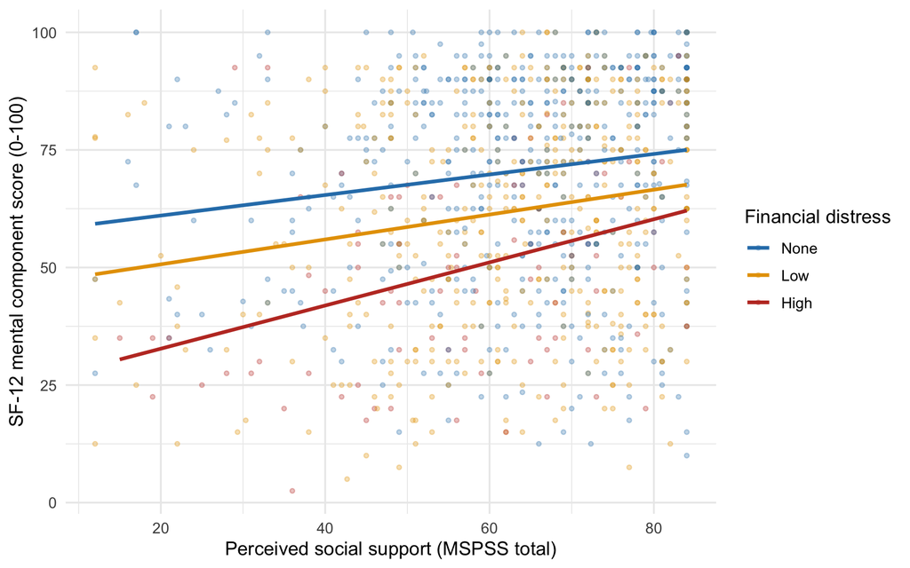

Figure 1. SF-12 mental component score against perceived social support, coloured by financial distress. Lines are linear smooths within financial-distress category.

## Univariable models

| **Characteristic** | **N** | **Beta** | **95% CI** | **p-value** |
| --- | --- | --- | --- | --- |
| age_yrs | 1,065 | -0.23 | -0.36, -0.10 | <0.001 |
| sex | 1,065 |  |  |  |
| Male |  | — | — |  |
| Female |  | -11 | -13, -7.8 | <0.001 |
| living_alone | 1,065 |  |  |  |
| No |  | — | — |  |
| Yes |  | -6.9 | -10, -3.8 | <0.001 |
| financial_distress | 1,065 |  |  |  |
| None |  | — | — |  |
| Low |  | -8.7 | -12, -5.9 | <0.001 |
| High |  | -21 | -26, -16 | <0.001 |
| disease | 1,065 |  |  |  |
| Type 2 diabetes |  | — | — |  |
| COPD |  | -8.0 | -12, -4.4 | <0.001 |
| Heart failure |  | -9.7 | -14, -5.8 | <0.001 |
| Renal disease |  | -2.8 | -6.7, 1.1 | 0.2 |
| charlson_index | 1,065 | -2.8 | -3.5, -2.0 | <0.001 |
| social_support_total | 1,065 | 0.31 | 0.22, 0.39 | <0.001 |

Abbreviation: CI = Confidence Interval

Financial distress is the strongest crude predictor: compared with patients reporting none, those with high distress score 20.96 SF-12 mental points lower (95% CI -26.01 to -15.92, p < 0.001) and those with low distress 8.75 points lower (p < 0.001) — an enormous gap on a 0-100 scale. Female sex is associated with a 10.66-point deficit (95% CI -13.48 to -7.83, p < 0.001). Each point of perceived social support is associated with a 0.31-point higher score (95% CI 0.22 to 0.40, p < 0.001), and each Charlson point with a 2.76-point lower score (95% CI -3.52 to -2.00). Living alone is crudely associated with a 6.89-point deficit (95% CI -9.98 to -3.79, p < 0.001). Crudely, heart failure (-9.70) and COPD (-7.99) sit below diabetes, while renal disease does not differ (p = 0.16).

## Why adjustment is needed

`social_support_total` is the key confounder of the living-alone association: people who live alone report substantially less perceived social support, and perceived support is itself strongly associated with mental wellbeing, so the crude living-alone deficit may be entirely a support effect wearing a different label. `financial_distress` is a second confounder, of both the disease contrasts and the sex contrast: financial strain is unevenly distributed across the four disease groups and between men and women in this sample, and it is by far the strongest correlate of the outcome. `charlson_index` is a third: it rises with age (r = 0.34), differs between disease groups, and independently predicts worse mental wellbeing, so both the crude age association and the crude COPD/heart-failure deficits partly reflect overall illness burden. Because the four disease groups were pooled by design and differ in age, sex and comorbidity, `disease` must be in the model for the other coefficients to be read as within-disease comparisons.

## Multivariable model

| **Characteristic** | **Beta** | **95% CI** | **p-value** |
| --- | --- | --- | --- |
| age_yrs | -0.13 | -0.26, 0.00 | 0.048 |
| sex |  |  |  |
| Male | — | — |  |
| Female | -11 | -13, -8.1 | <0.001 |
| living_alone |  |  |  |
| No | — | — |  |
| Yes | -0.28 | -3.2, 2.7 | 0.9 |
| financial_distress |  |  |  |
| None | — | — |  |
| Low | -6.7 | -9.3, -4.0 | <0.001 |
| High | -18 | -23, -14 | <0.001 |
| disease |  |  |  |
| Type 2 diabetes | — | — |  |
| COPD | -6.5 | -9.8, -3.3 | <0.001 |
| Heart failure | -6.0 | -9.9, -2.2 | 0.002 |
| Renal disease | 1.6 | -2.3, 5.5 | 0.4 |
| charlson_index | -2.7 | -3.5, -1.9 | <0.001 |
| social_support_total | 0.26 | 0.17, 0.34 | <0.001 |

Abbreviation: CI = Confidence Interval

Model fit

| Statistic | Value |
| --- | --- |
| R-squared | 0.219 |
| Adjusted R-squared | 0.212 |
| Residual SE | 20.810 |
| N | 1065.000 |
| Model df | 10.000 |

Conditional on all other predictors, high financial distress remains associated with an 18.32-point lower SF-12 mental score than no distress (95% CI -23.12 to -13.53, p < 0.001) and low distress with a 6.66-point deficit (95% CI -9.30 to -4.02, p < 0.001). Female sex retains a 10.78-point deficit (95% CI -13.43 to -8.14, p < 0.001), each point of social support a 0.26-point advantage (95% CI 0.17 to 0.34, p < 0.001) and each Charlson point a 2.68-point deficit (95% CI -3.50 to -1.85, p < 0.001). COPD (-6.55, 95% CI -9.79 to -3.30) and heart failure (-6.04, 95% CI -9.86 to -2.23) remain below diabetes; renal disease does not differ (p = 0.43). Living alone is now essentially null (-0.28, 95% CI -3.23 to 2.67, p = 0.85), and age is only borderline (-0.13 per year, p = 0.048). The model explains R² = 0.219 of the variance (adjusted R² = 0.212).

## Unadjusted versus adjusted

**Table 2. Unadjusted and adjusted estimates.**

| **Characteristic** | **Unadjusted** **N** | **Unadjusted** **Beta** | **Unadjusted** **95% CI** | **Unadjusted** **p-value** | **Adjusted** **Beta** | **Adjusted** **95% CI** | **Adjusted** **p-value** |
| --- | --- | --- | --- | --- | --- | --- | --- |
| age_yrs | 1,065 | -0.23 | -0.36, -0.10 | <0.001 | -0.13 | -0.26, 0.00 | 0.048 |
| sex | 1,065 |  |  |  |  |  |  |
| Male |  | — | — |  | — | — |  |
| Female |  | -11 | -13, -7.8 | <0.001 | -11 | -13, -8.1 | <0.001 |
| living_alone | 1,065 |  |  |  |  |  |  |
| No |  | — | — |  | — | — |  |
| Yes |  | -6.9 | -10, -3.8 | <0.001 | -0.28 | -3.2, 2.7 | 0.9 |
| financial_distress | 1,065 |  |  |  |  |  |  |
| None |  | — | — |  | — | — |  |
| Low |  | -8.7 | -12, -5.9 | <0.001 | -6.7 | -9.3, -4.0 | <0.001 |
| High |  | -21 | -26, -16 | <0.001 | -18 | -23, -14 | <0.001 |
| disease | 1,065 |  |  |  |  |  |  |
| Type 2 diabetes |  | — | — |  | — | — |  |
| COPD |  | -8.0 | -12, -4.4 | <0.001 | -6.5 | -9.8, -3.3 | <0.001 |
| Heart failure |  | -9.7 | -14, -5.8 | <0.001 | -6.0 | -9.9, -2.2 | 0.002 |
| Renal disease |  | -2.8 | -6.7, 1.1 | 0.2 | 1.6 | -2.3, 5.5 | 0.4 |
| charlson_index | 1,065 | -2.8 | -3.5, -2.0 | <0.001 | -2.7 | -3.5, -1.9 | <0.001 |
| social_support_total | 1,065 | 0.31 | 0.22, 0.39 | <0.001 | 0.26 | 0.17, 0.34 | <0.001 |

Abbreviation: CI = Confidence Interval

## Diagnostics

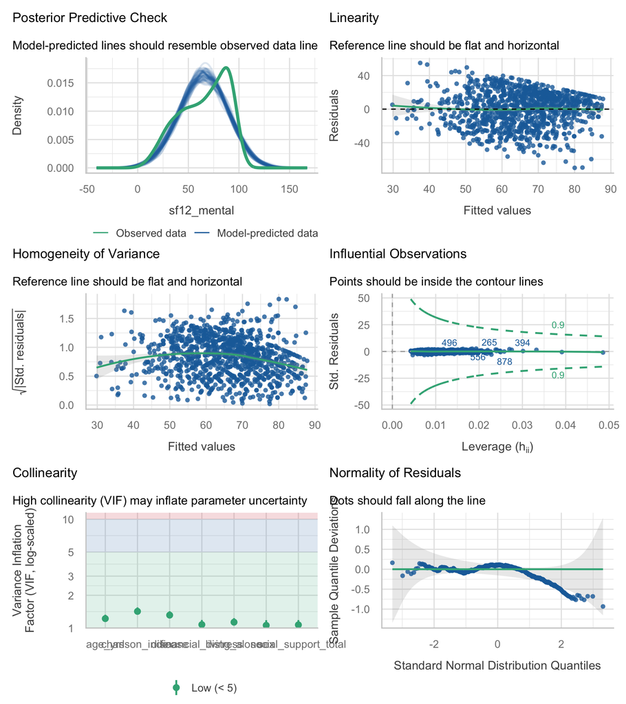

| Term | VIF | VIF_CI_low | VIF_CI_high | SE_factor | Tolerance | Tolerance_CI_low | Tolerance_CI_high |
| --- | --- | --- | --- | --- | --- | --- | --- |
| age_yrs | 1.221077 | 1.150158 | 1.325489 | 1.105023 | 0.8189495 | 0.7544383 | 0.8694458 |
| sex | 1.058797 | 1.019048 | 1.181492 | 1.028979 | 0.9444679 | 0.8463875 | 0.9813077 |
| living_alone | 1.132194 | 1.074971 | 1.233093 | 1.064046 | 0.8832409 | 0.8109691 | 0.9302575 |
| financial_distress | 1.074955 | 1.030180 | 1.186159 | 1.018234 | 0.9302717 | 0.8430574 | 0.9707045 |
| disease | 1.314326 | 1.231177 | 1.427382 | 1.046608 | 0.7608462 | 0.7005831 | 0.8122311 |
| charlson_index | 1.423120 | 1.326658 | 1.548067 | 1.192946 | 0.7026813 | 0.6459668 | 0.7537735 |
| social_support_total | 1.069661 | 1.026411 | 1.183732 | 1.034244 | 0.9348759 | 0.8447861 | 0.9742682 |

Linearity is acceptable. Homogeneity of variance fails: `check_heteroscedasticity()` rejects constant error variance (p = 0.009). This is expected from a ceiling-bounded score — patients predicted to be near 90 have little room to vary upwards, while those predicted around 50 vary in both directions — and it shows as a funnel narrowing to the right. Normality of residuals is also rejected (p < 0.001), reflecting the left skew and the fact that `sf12_mental` takes only 65 distinct values. Collinearity is not a problem (all VIFs below 1.5, largest `charlson_index` 1.42), and no observation exceeds the Cook’s distance threshold.

Because heteroscedasticity was flagged, the model was re-tested with HC3 heteroscedasticity-consistent standard errors:

HC3 robust standard errors

Compared with the model-based standard errors

| Term | Estimate | Model SE | HC3 SE | HC3 p |
| --- | --- | --- | --- | --- |
| (Intercept) | 77.036 | 5.276 | 5.617 | <0.001 |
| age_yrs | -0.129 | 0.065 | 0.069 | 0.061 |
| sexFemale | -10.783 | 1.348 | 1.364 | <0.001 |
| living_aloneYes | -0.283 | 1.503 | 1.508 | 0.851 |
| financial_distressLow | -6.660 | 1.346 | 1.367 | <0.001 |
| financial_distressHigh | -18.325 | 2.442 | 2.464 | <0.001 |
| diseaseCOPD | -6.546 | 1.653 | 1.715 | <0.001 |
| diseaseHeart failure | -6.042 | 1.944 | 1.954 | 0.002 |
| diseaseRenal disease | 1.574 | 1.977 | 1.936 | 0.416 |
| charlson_index | -2.678 | 0.421 | 0.438 | <0.001 |
| social_support_total | 0.256 | 0.042 | 0.046 | <0.001 |

The robust standard errors are within about 10% of the model-based ones for every term (largest inflation: `social_support_total`, 9.5%; `age_yrs`, 5.4%), and only one conclusion is affected: `age_yrs` moves from marginally significant under model-based inference (p = 0.048) to non-significant under HC3 (p = 0.061). Since that estimate sits on the threshold either way, the honest reading is that age has no reliable independent association here. Every other conclusion is unchanged.

# Discussion

Among Dutch adults with one of four chronic conditions, financial distress and female sex are the characteristics most strongly and independently associated with poor mental health-related quality of life, followed by low perceived social support and higher comorbidity burden. Living alone, which looks important on its own, adds nothing once perceived support is accounted for — what matters is whether patients feel supported, not whether there is someone in the house. Practically, this argues for asking chronic-disease patients about money and about felt support rather than recording household composition.

**Limitations.** The design is cross-sectional, and the direction of the social-support and financial-distress associations is genuinely ambiguous: poor mental wellbeing plausibly leads people to perceive both their finances and their support networks more negatively. Support, distress and the SF-12 are all self-reported at the same sitting, so common-method bias inflates those associations. The file has no disease-specific severity markers — no eGFR or dialysis status, no NYHA class, no GOLD stage — so severity is represented only by the generic Charlson index and the `disease` coefficients carry residual confounding. The high financial-distress cell has fewer than 100 participants, so that large estimate is also the least precise. Error variance is non-constant and residuals are non-normal; HC3 standard errors were reported and changed only the borderline age result. Complete-case analysis dropped 89 participants (7.7%). All estimates are associations, not effects.

**Future work.** Measuring support and mood repeatedly over a year would show whether changes in perceived support precede changes in wellbeing or follow them.

# Feasibility notes

*Not part of a student report.*

- **Works well.** Large, clearly interpretable effects; a memorable confounding story (`living_alone` collapsing once social support is adjusted for); and a legitimate reason to reach for robust standard errors.
- **Complete-case N = 1065** of 1154 (89 dropped, 7.7%).
- **Heteroscedasticity flagged** (p = 0.009) and normality rejected. HC3 SEs flip only the borderline `age_yrs` result (p = 0.048 to p = 0.061), which is a good, non-catastrophic illustration of why robust SEs matter.
- **The sibling / same-construct trap is worst for this outcome.** Three variables in the file are near-restatements of `sf12_mental`: `sf12_physical` (VIF only 1.38 but takes adjusted R² from 0.22 to 0.59), `hads_depression` (r = -0.71; adjusted R² to 0.56) and `hads_anxiety` (r = -0.68). None of them trips a VIF alarm, so students who screen only on VIF will keep them and report a meaningless “finding”. This outcome needs the most explicit predictor guardrails of the five.
- **No collinearity problem** in the chosen set: max VIF 1.42.
- **Sparse cell**: `financial_distress = high` has fewer than 100 participants and produces the largest coefficient in the model; fine for a main effect, unusable for interactions.